# DATA624 Project-1

### ATM4

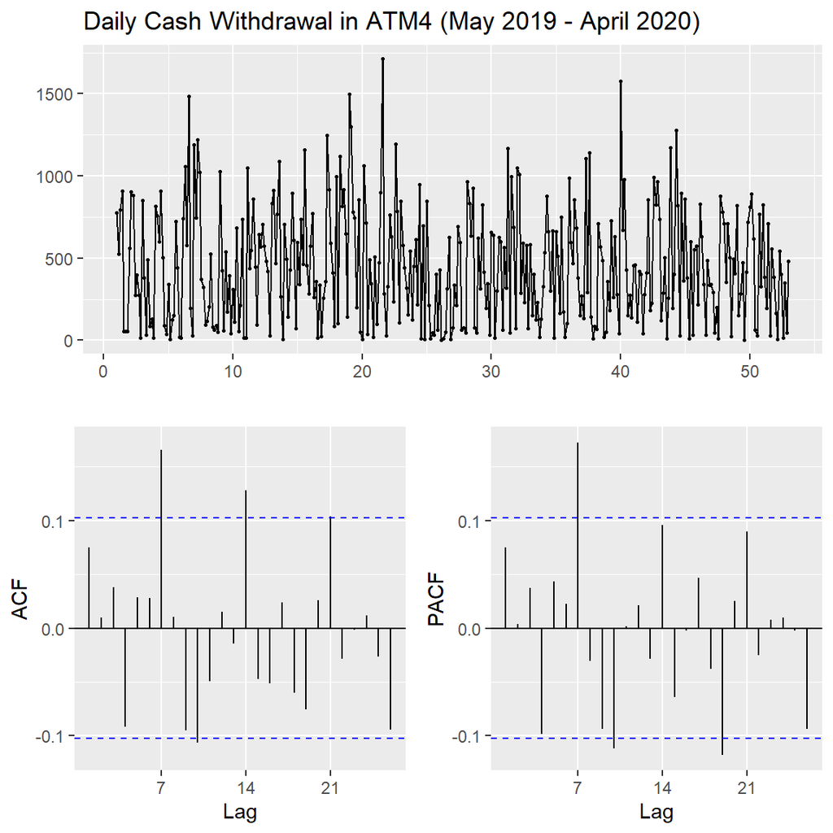

```r
ggtsdisplay(atm4, main="Daily Cash Withdrawal in ATM4 (May 2019 - April 2020)")
```

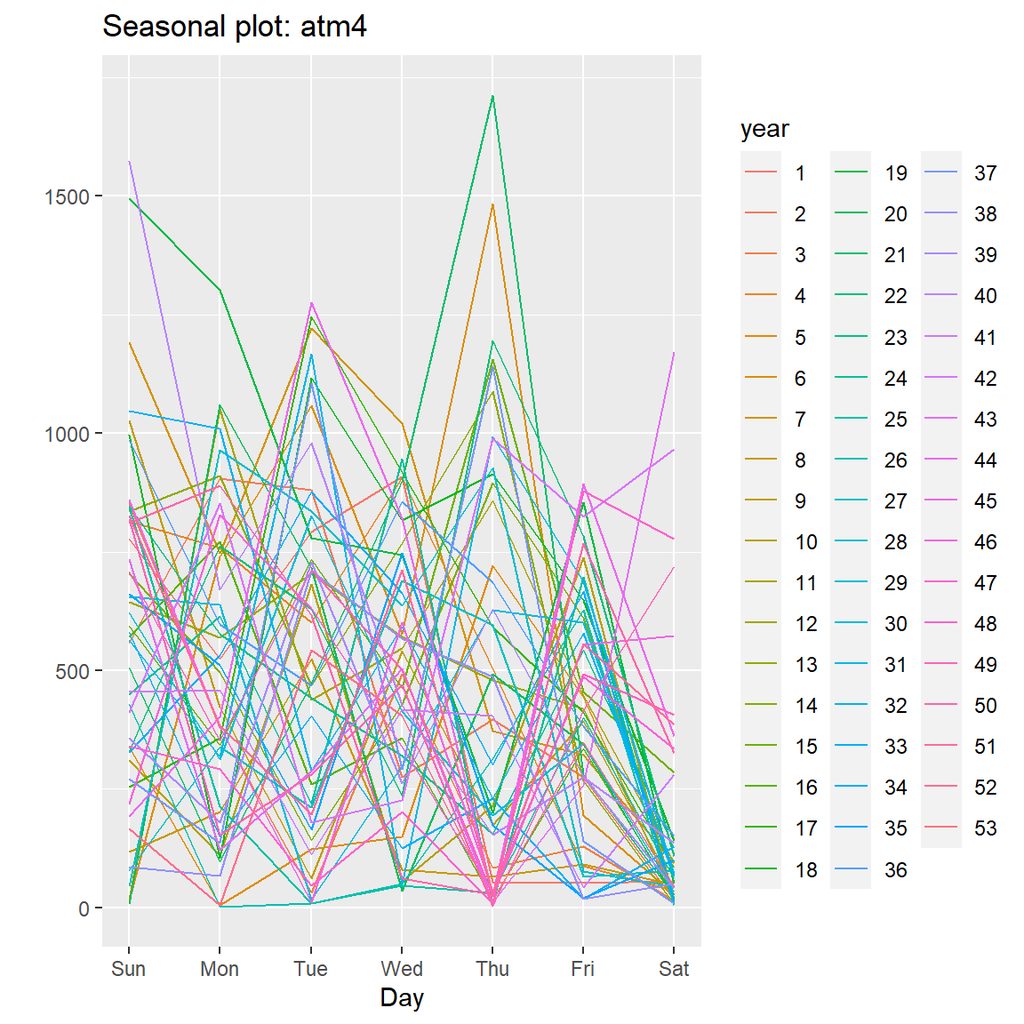

```r
ggseasonplot(atm4)
```

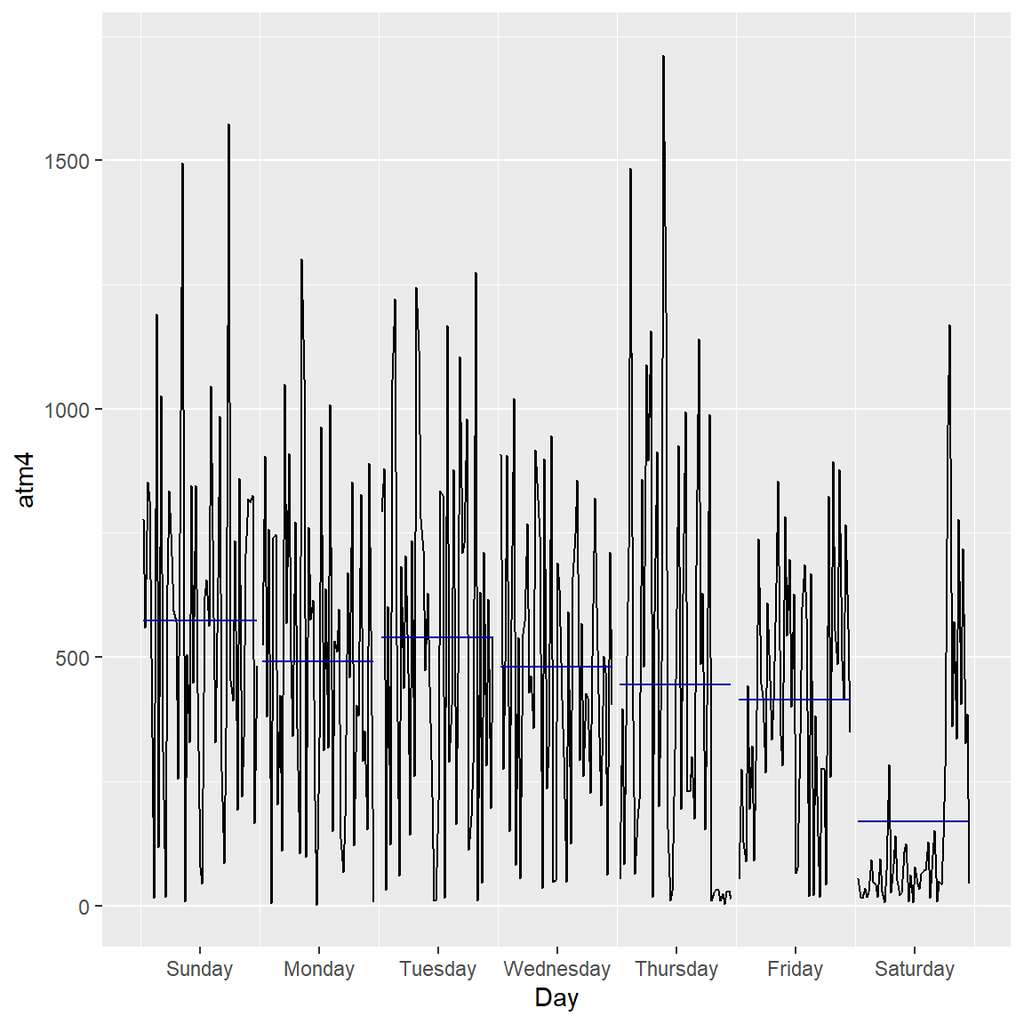

```r
ggsubseriesplot(atm4)
```

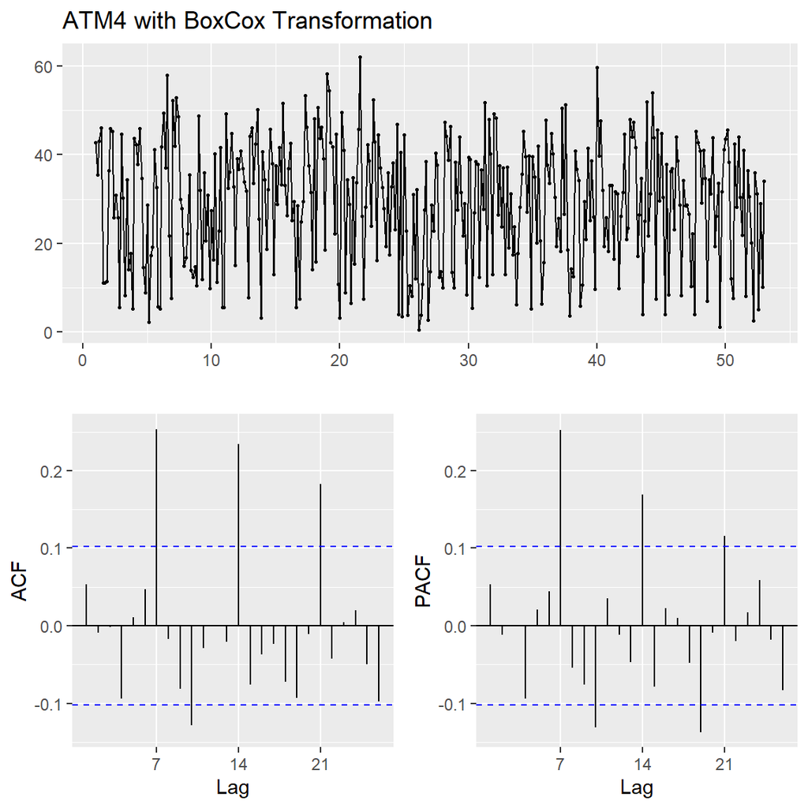

```r
atm4_bc <- BoxCox(atm4, lambda = BoxCox.lambda(atm4))
ggtsdisplay(atm4_bc, main="ATM4 with BoxCox Transformation")
```

After applying Box-Cox transformation, we still see the weekly seasonality in the timeseries. Differencing is needed.

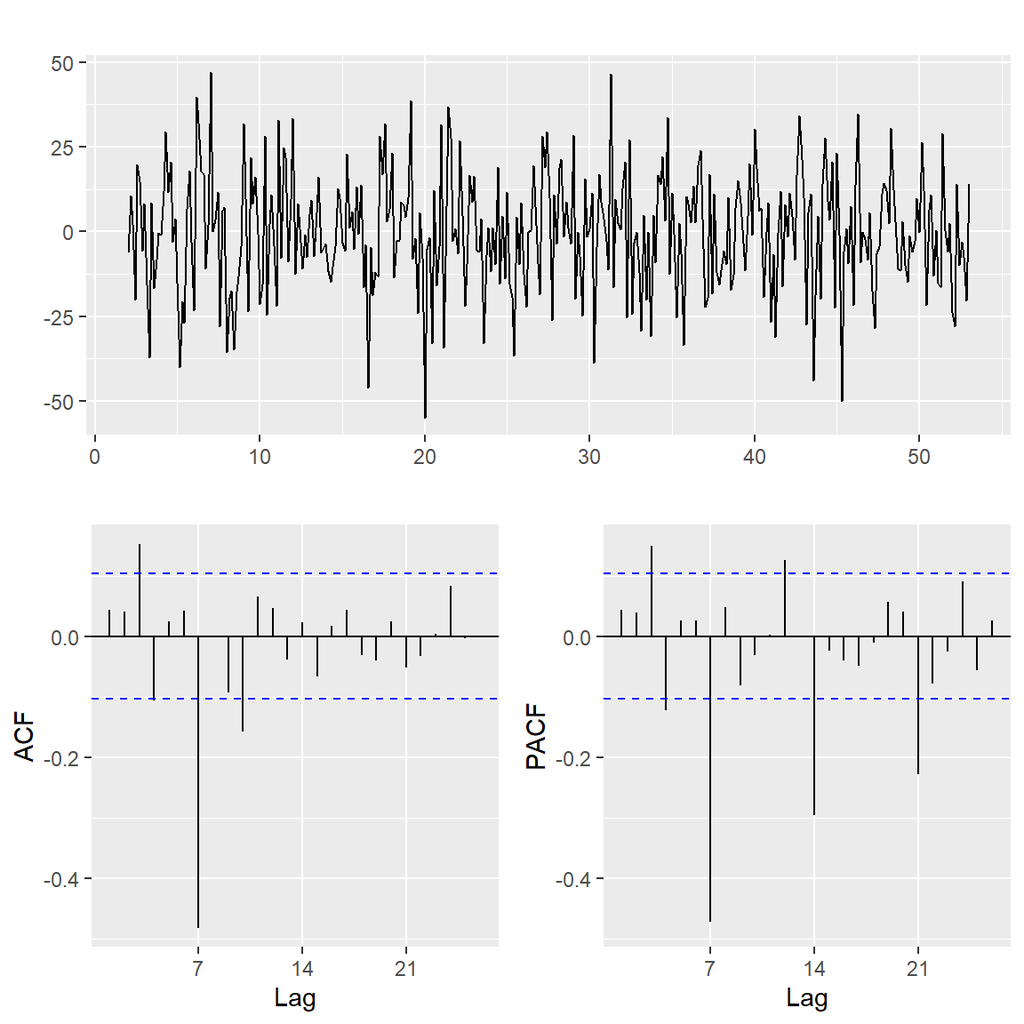

```r
ggtsdisplay(diff(atm4_bc, 7), points=FALSE)
```

```r
atm4_bc %>% diff() %>% ur.kpss() %>% summary()
```

```
##
## #######################
## # KPSS Unit Root Test #
## #######################
##
## Test is of type: mu with 5 lags.
##
## Value of test-statistic is: 0.0124
##
## Critical value for a significance level of:
##                 10pct  5pct 2.5pct  1pct
## critical values 0.347 0.463  0.574 0.739
```

```r
atm4_arima <- Arima(atm4, order=c(1,0,1), seasonal=c(0,1,1), lambda = BoxCox.lambda(atm4))
summary(atm4_arima)
```

```
## Series: atm4
## ARIMA(1,0,1)(0,1,1)[7]
## Box Cox transformation: lambda= 0.4525697
##
## Coefficients:
##          ar1      ma1     sma1
##       0.6851  -0.6059  -0.8677
## s.e.  0.3040   0.3315   0.0315
##
## sigma^2 = 171.4:  log likelihood = -1432.08
## AIC=2872.16   AICc=2872.27   BIC=2887.68
##
## Training set error measures:
##                    ME     RMSE      MAE       MPE     MAPE      MASE      ACF1
## Training set 61.63608 337.5467 254.8181 -360.8151 404.2179 0.7355835 0.0185852
```

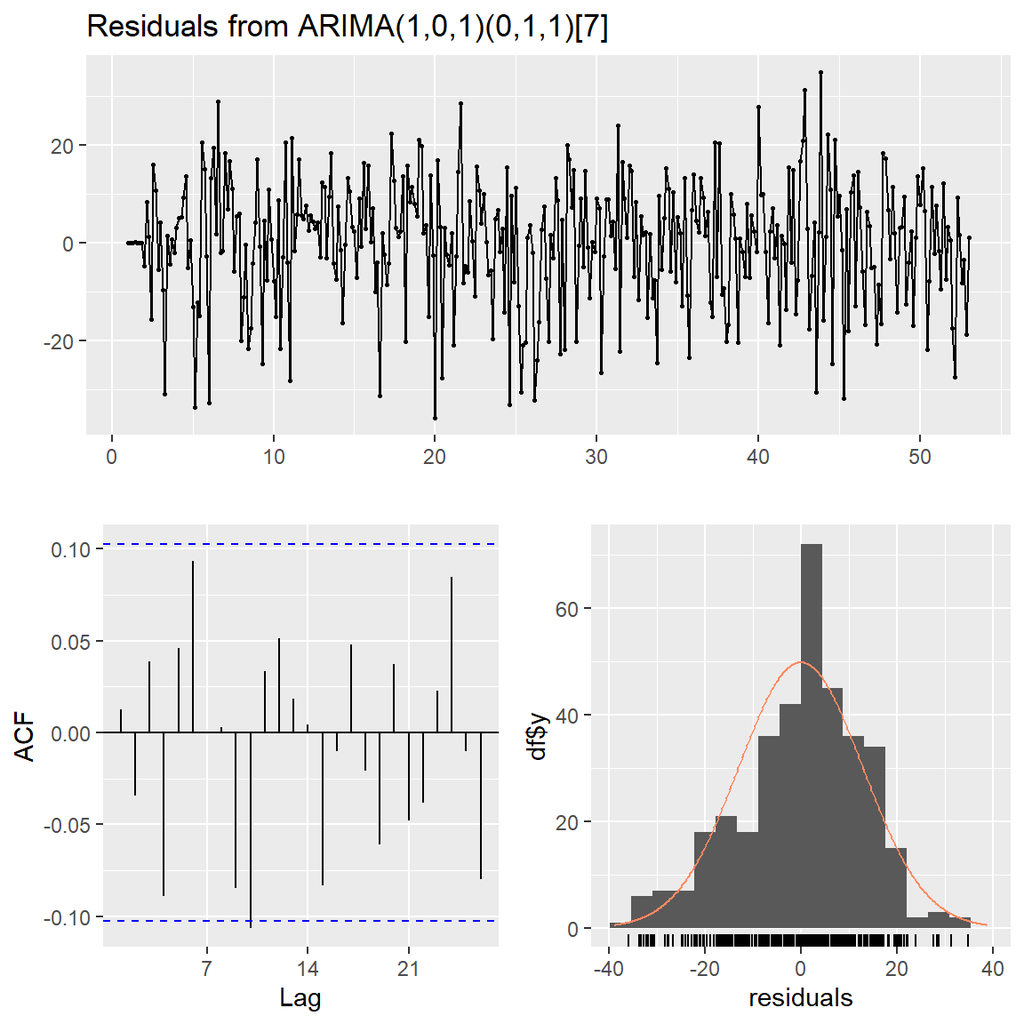

```
##
##  Ljung-Box test
##
## data:  Residuals from ARIMA(1,0,1)(0,1,1)[7]
## Q* = 16.519, df = 11, p-value = 0.1229
##
## Model df: 3.   Total lags used: 14
```

```r
checkresiduals(atm4_arima)
```

Now, let’s use auto.arima to find out which is the best Arima model:

```r
atm4_auto <- auto.arima(atm4, approximation = FALSE, lambda=BoxCox.lambda(atm4))
summary(atm4_auto)
```

```
## Series: atm4
## ARIMA(1,0,0)(2,0,0)[7] with non-zero mean
## Box Cox transformation: lambda= 0.4525697
##
## Coefficients:
##          ar1    sar1    sar2     mean
##       0.0771  0.2090  0.1996  29.0082
## s.e.  0.0526  0.0516  0.0525   1.2627
##
## sigma^2 = 182.2:  log likelihood = -1466.34
## AIC=2942.69   AICc=2942.85   BIC=2962.19
##
## Training set error measures:
##                    ME     RMSE      MAE       MPE     MAPE      MASE       ACF1
## Training set 84.38613 351.7695 274.2406 -370.6751 415.1343 0.7916504 0.01960666
```

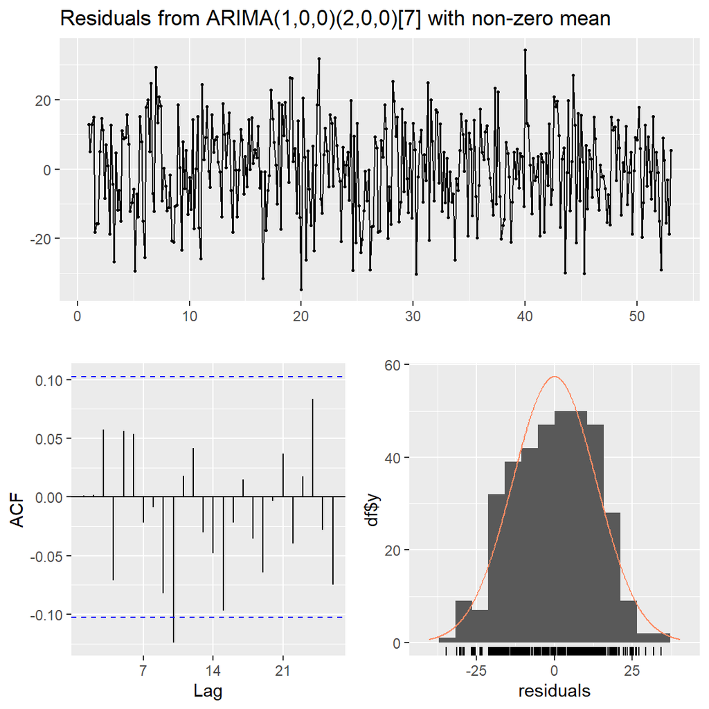

```
##
##  Ljung-Box test
##
## data:  Residuals from ARIMA(1,0,0)(2,0,0)[7] with non-zero mean
## Q* = 15.92, df = 11, p-value = 0.1441
##
## Model df: 3.   Total lags used: 14
```

```r
checkresiduals(atm4_auto)
```

The ARIMA model found by ‘auto.arima’ is ARIMA(1,0,0)(2,0,0)[7]. The ARIMA model I suggested is ARIMA(1,0,1)(0,1,1)[7].The model I suggested has smaller AICc and RMSE.I think that the best model is the model that I suggested.

```r
atm4_model <- Arima(atm4, order=c(1,0,1), seasonal=c(0,1,1), lambda = BoxCox.lambda(atm4))
```

## Forecast

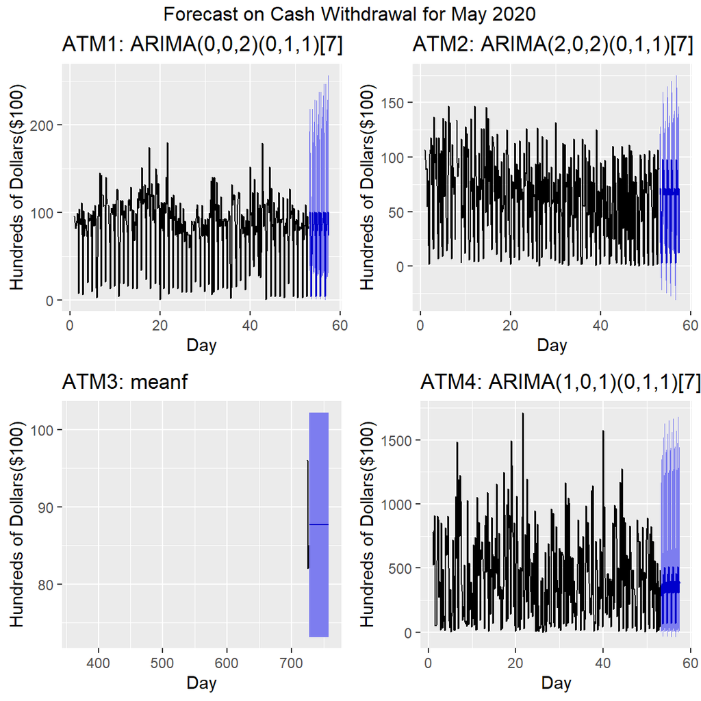

```r
atm1_f <- forecast(atm1_model, 31, level=95)
atm2_f <- forecast(atm2_model, 31, level=95)
atm3_f <- meanf(atm3, 31, level=95)
atm4_f <- forecast(atm4_model, 31, level=95)

gridExtra::grid.arrange(
  autoplot(atm1_f) +
    labs(title="ATM1: ARIMA(0,0,2)(0,1,1)[7]", x="Day", y="Hundreds of Dollars($100)"),
  autoplot(atm2_f) +
    labs(title="ATM2: ARIMA(2,0,2)(0,1,1)[7]", x="Day", y="Hundreds of Dollars($100)"),
  autoplot(atm3_f) +
    labs(title="ATM3: meanf", x="Day", y="Hundreds of Dollars($100)"),
  autoplot(atm4_f) +
    labs(title="ATM4: ARIMA(1,0,1)(0,1,1)[7]", x="Day", y="Hundreds of Dollars($100)"),
  top = grid::textGrob("Forecast on Cash Withdrawal for May 2020")
)
```

```r
export <- rbind(atm1_f$mean, atm2_f$mean, atm3_f$mean, atm4_f$mean)
write.csv(export, "ATM_Forecast.csv")

data.frame(export) %>% cbind(ATM = c('ATM1', 'ATM2', 'ATM3', 'ATM4')) %>%
                    select(ATM, everything())
```

```
##    ATM        X1        X2        X3        X4        X5        X6        X7
## 1 ATM1  86.74294 100.55515  73.62242  4.211032 100.14543  79.32380  85.78103
## 2 ATM2  65.64590  71.57733  11.87248  2.741321  97.99480  88.96331  65.68584
## 3 ATM3  87.66667  87.66667  87.66667 87.666667  87.66667  87.66667  87.66667
## 4 ATM4 280.99138 363.04960 380.34153 64.998646 449.24378 303.25757 507.37695
##          X8        X9       X10       X11       X12       X13       X14
## 1  87.22992 100.36819  73.62242  4.211032 100.14543  79.32380  85.78103
## 2  65.66859  71.59474  11.85550  2.739787  98.02444  88.95494  65.66519
## 3  87.66667  87.66667  87.66667 87.666667  87.66667  87.66667  87.66667
## 4 306.98773 383.34690 394.53535 68.714726 456.49955 307.26292 511.00791
##         X15       X16       X17       X18       X19       X20       X21
## 1  87.22992 100.36819  73.62242  4.211032 100.14543  79.32380  85.78103
## 2  65.68416  71.60715  11.84374  2.738603  98.04512  88.94938  65.65068
## 3  87.66667  87.66667  87.66667 87.666667  87.66667  87.66667  87.66667
## 4 308.87651 384.80722 395.55131 68.982178 457.01579 307.54766 511.26558
##         X22       X23       X24       X25       X26       X27       X28
## 1  87.22992 100.36819  73.62242  4.211032 100.14543  79.32380  85.78103
## 2  65.69484  71.61598  11.83559  2.737698  98.05954  88.94570  65.64048
## 3  87.66667  87.66667  87.66667 87.666667  87.66667  87.66667  87.66667
## 4 309.01050 384.91075 395.62331 69.001140 457.05236 307.56783 511.28383
##         X29       X30       X31
## 1  87.22992 100.36819  73.62242
## 2  65.70216  71.62226  11.82995
## 3  87.66667  87.66667  87.66667
## 4 309.01999 384.91809 395.62841
```

Export the results Forecast of ATM1, ATM2, ATM3 and ATM4 en el file: ‘ATM_Forecast.csv’

I think that the ATM1 and ATM2 forecasts seem correct, but in the case of ATM4, the generated forecast does not seem to follow the pattern of the data, I do not think the forecast is reliable, suddenly it is necessary to apply another type of model.

# Part B – Forecasting Power

## Objetive

The goal of the project is to explore time series, decomposition, forecasting, data preprocessing, exponential smoothing, and ARIMA.

## Load Data

First, load the excel data into R and clean it by using function ‘tsclean()’ which can handle outliers and NA value.

```r
kwh <- import("https://raw.githubusercontent.com/GabrielSantos33/DATA624_Project1/main/ResidentialCustomerForecastLoad-624.xlsx")
kwh_ts <- ts(kwh[,"KWH"], start=c(1998,1), frequency=12) %>%
  tsclean()
kwh_ts
```

```
##           Jan      Feb      Mar      Apr      May      Jun      Jul      Aug
## 1998  6862583  5838198  5420658  5010364  4665377  6467147  8914755  8607428
## 1999  7183759  5759262  4847656  5306592  4426794  5500901  7444416  7564391
## 2000  7068296  5876083  4807961  4873080  5050891  7092865  6862662  7517830
## 2001  7538529  6602448  5779180  4835210  4787904  6283324  7855129  8450717
## 2002  7099063  6413429  5839514  5371604  5439166  5850383  7039702  8058748
## 2003  7256079  6190517  6120626  4885643  5296096  6051571  6900676  8476499
## 2004  7584596  6560742  6526586  4831688  4878262  6421614  7307931  7309774
## 2005  8225477  6564338  5581725  5563071  4453983  5900212  8337998  7786659
## 2006  7793358  5914945  5819734  5255988  4740588  7052275  7945564  8241110
## 2007  8031295  7928337  6443170  4841979  4862847  5022647  6426220  7447146
## 2008  7964293  7597060  6085644  5352359  4608528  6548439  7643987  8037137
## 2009  8072330  6976800  5691452  5531616  5264439  5804433  7713260  8350517
## 2010  9397357  8390677  7347915  5776131  4919289  6696292  7686742  7922701
## 2011  8394747  8898062  6356903  5685227  5506308  8037779 10093343 10308076
```

[output cut: 19 more lines]

```r
summary(kwh[,"KWH"]) #before
```

```
##     Min.  1st Qu.   Median     Mean  3rd Qu.     Max.     NA's
##   770523  5429912  6283324  6502475  7620524 10655730        1
```

```r
summary(kwh_ts)
```

```
##     Min.  1st Qu.   Median     Mean  3rd Qu.     Max.
##  4313019  5443502  6351262  6529723  7608792 10655730
```

## Timeseries

Now, let’s convert the data into a time series.

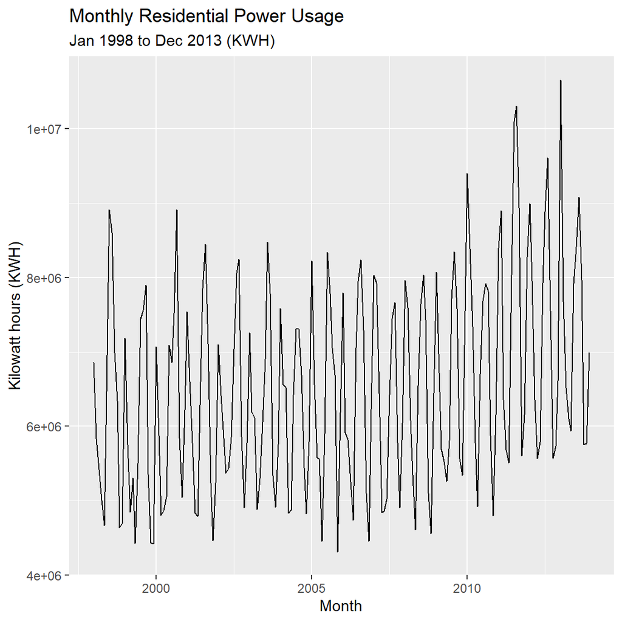

```r
autoplot(kwh_ts) +
  ggtitle("Monthly Residential Power Usage", subtitle = "Jan 1998 to Dec 2013 (KWH)") +
  xlab("Month") +
  ylab("Kilowatt hours (KWH)")
```

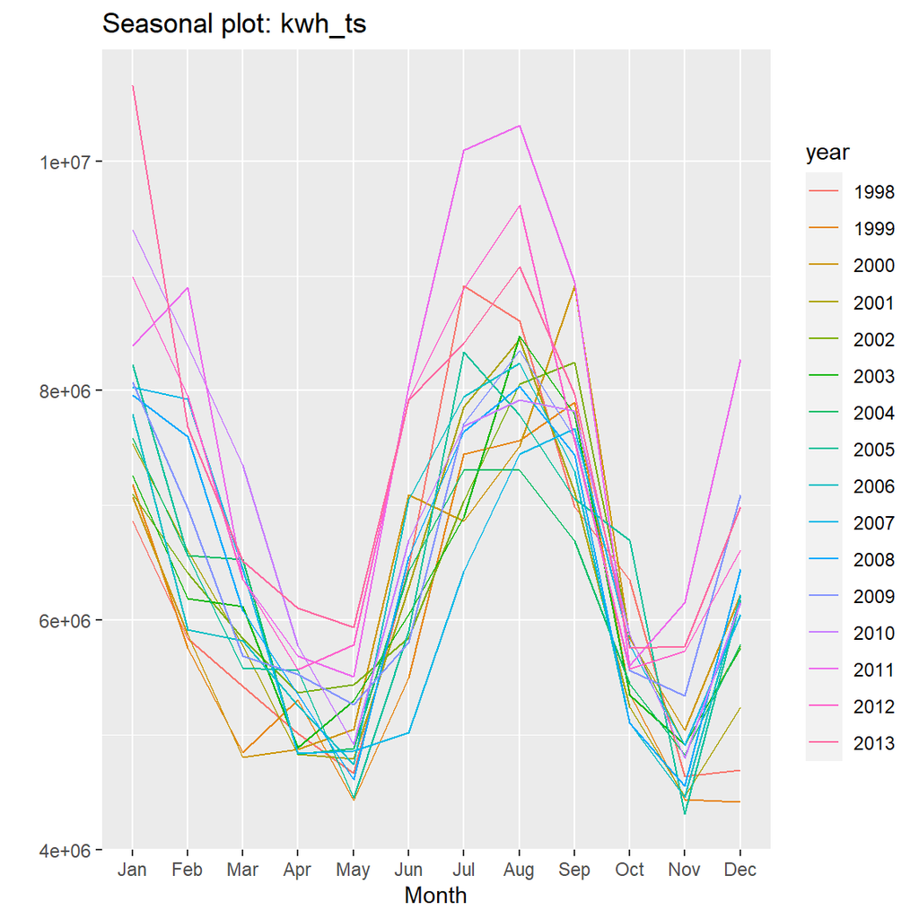

```r
ggseasonplot(kwh_ts)
```

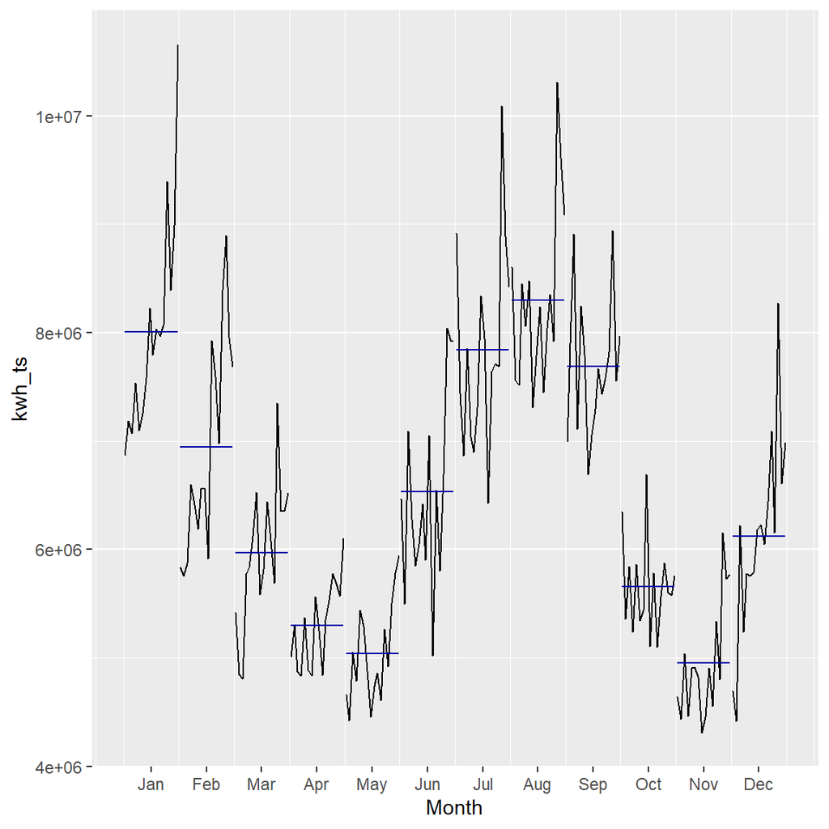

```r
ggsubseriesplot(kwh_ts)
```

Seasonality is found in this timeseries and appears to have a peak every 6 months. The seasonality may be annual due to the high power usage during winter and summer.

## ARIMA Model

We see annual seasonality.

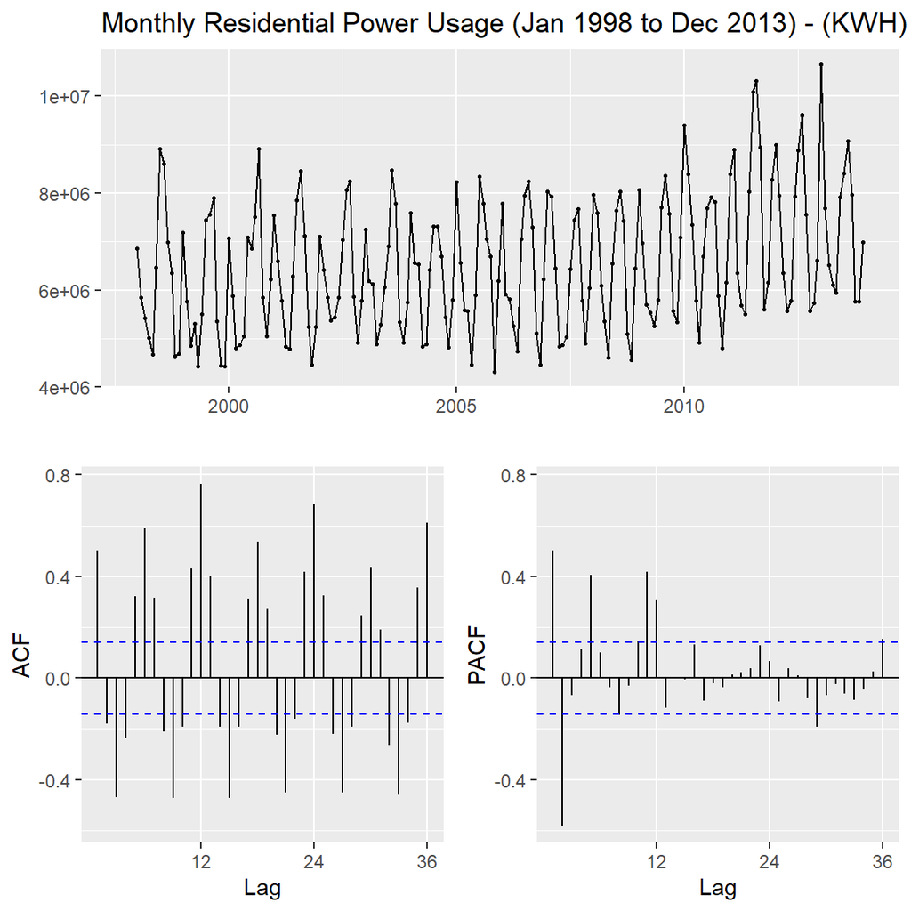

```r
ggtsdisplay(kwh_ts, main="Monthly Residential Power Usage (Jan 1998 to Dec 2013) - (KWH)")
```

We apply the BoxCox Transformation:

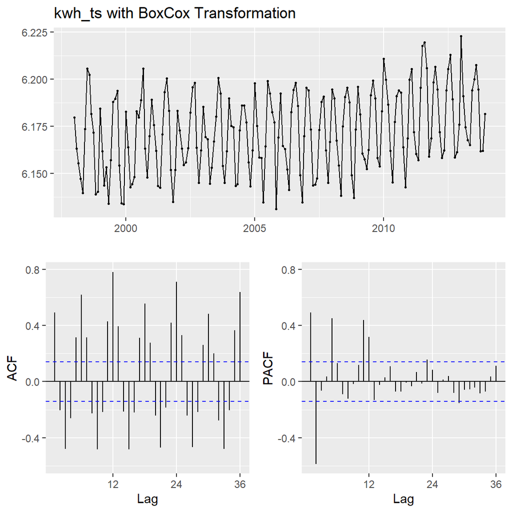

```r
kwh_bc <- BoxCox(kwh_ts, lambda = BoxCox.lambda(kwh_ts))
ggtsdisplay(kwh_bc, main="kwh_ts with BoxCox Transformation")
```

Tried Box-Cox transformation on the timeseries but no huge differences. Will work on differencing instead.

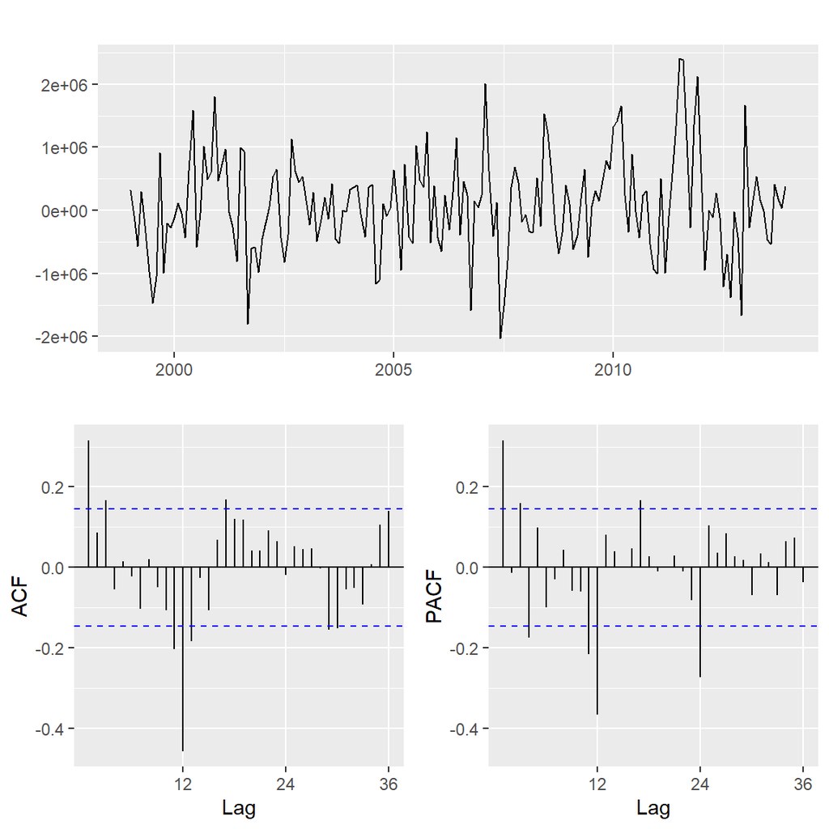

```r
ggtsdisplay(diff(kwh_ts,12), points=FALSE)
```

```r
kwh_ts %>% diff(.,12) %>% ur.kpss() %>% summary()
```

```
##
## #######################
## # KPSS Unit Root Test #
## #######################
##
## Test is of type: mu with 4 lags.
##
## Value of test-statistic is: 0.1159
##
## Critical value for a significance level of:
##                 10pct  5pct 2.5pct  1pct
## critical values 0.347 0.463  0.574 0.739
```

After differencing once, the timeseries now appears to be stationary. ARIMA(p,d,q)(P,D,Q)[m] model has p/P as order of the autoregressive part, d/D as degree of first differencing involved, q/Q as order of the moving average part, and m as number of observations. The non-seasonal significant lag1 in ACF and PACF suggest non-seasonal p=q=1.